# HW2

Alexander Hyde  
Phys 434 AB  
Homework 2

```python
%matplotlib inline
import numpy as np
import math
import matplotlib
import matplotlib.pyplot as plt
import scipy
from scipy import stats
```

Q1. $ \frac16 \cdot \frac16 = \frac1{36} $ chance to roll two ones  
To sum up to 7, you can roll 1 + 6, 2 + 5, 3 + 4, 4 + 3, 5 + 2, or 6 + 1. Each of these 6 rolls has a $\frac1{36}$ chance, summed together that's a $\frac16$ chance to sum two rolls into 7.

Q2. P(x) is the probability of the two dice rolling a sum of x, where x is any integer between 2 and 12.  
x = 2: 1 + 1  
x = 3: 1 + 2, 2 + 1  
x = 4: 1 + 3, 2 + 2, 3 + 1  
x = 5: 1 + 4, 2 + 3, 3 + 2, 4 + 1  
x = 6: 1 + 5, 2 + 4, 3 + 3, 4 + 2, 5 + 1  
x = 7: 1 + 6, 2 + 5, 3 + 4, 4 + 3, 5 + 2, 6 + 1  
x = 8: 2 + 6, 3 + 5, 4 + 4, 5 + 3, 6 + 2  
x = 9: 3 + 6, 4 + 5, 5 + 4, 6 + 3  
x = 10: 4 + 6, 5 + 5, 6 + 4  
x = 11: 5 + 6, 6 + 5  
x = 12: 6 + 6  
Dividing the number of sums by 36 would give you the probability P(x) for that respective x.  
A more compact way of showing this method is by taking the summation:  
$P(x) = \sum_{i=1}^{6} {p(i) \cdot p(x-i)}$ where $p(x) = \frac16$ when $1 \leq x \leq 6$ and $p(x) = 0$ otherwise.

In Numpy, there's a command called numpy.convolve which does this automatically:

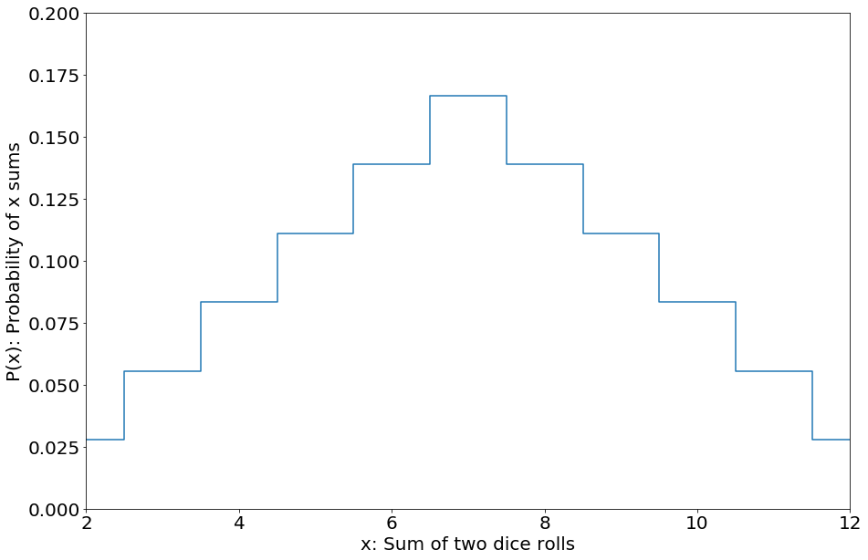

```python
p = np.multiply(np.ones(6),1/6)
P = np.convolve(p,p)

plt.rcParams["figure.figsize"] = (15,10)
fig, ax = plt.subplots(1, 1)
plt.xlim([2,12])
plt.ylim([0,0.2])
plt.tick_params(labelsize = 20)
plt.xlabel("x: Sum of two dice rolls",fontsize=20)
plt.ylabel("P(x): Probability of x sums",fontsize=20)
plt.step(range(2,13),P,where="mid")
plt.show()
```

Q3.

```python
x = range(2,13)
mean = sum(np.multiply(x,P))/sum(P)
sqDiff = np.multiply(np.square(np.add(x,-mean)),P)
variance = sum(sqDiff)
sDev = math.sqrt(variance)
print("Mean = " + str(mean))
print("Variance = " + str(variance))
print("Standard Deviation = " + str(sDev))
```

```
Mean = 6.999999999999998
Variance = 5.833333333333332
Standard Deviation = 2.4152294576982394
```

Q4.

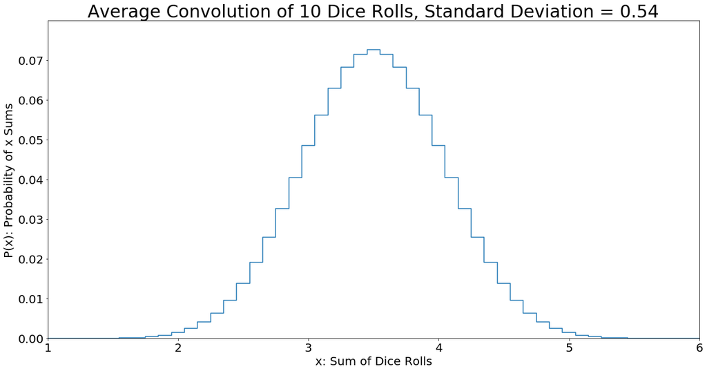

```python
def rollDice(d,div): # div = 1 for sum, div = 1/d for average
    p = np.multiply(np.ones(6),1/6)
    P = p
    for i in range(0,d-1):
        P = np.convolve(P,p)

    x = np.multiply(range(d,6*d+1),div)
    mean = sum(np.multiply(x,P))/sum(P)
    sqDiff = np.multiply(np.square(np.add(x,-mean)),P)
    variance = sum(sqDiff)
    sDev = math.sqrt(variance)

    plt.xlim(np.multiply([d,6*d],div))
    plt.ylim([0,1.1*max(P)])
    plt.step(x,P,where="mid")
    return sDev

plt.rcParams["figure.figsize"] = (20,10)
fig, ax = plt.subplots(1, 1)
sDev = rollDice(10,1/10)

plt.tick_params(labelsize = 20)
plt.title("Average Convolution of " + str(d) + " Dice Rolls, Standard Deviation = " + str(round(sDev,3)),fontsize=30)
plt.xlabel("x: Sum of Dice Rolls",fontsize=20)
plt.ylabel("P(x): Probability of x Sums",fontsize=20)
plt.show()
```

This graph isn't exactly a Gaussian distribution, but it resembles the shape. I say this because each extra dice added to the convolution adjusts its shape little by little, until after infinite dice, the net convolution effectively becomes a Gaussian. You can't look at a 2 dice or 3 dice convolution and say that looks exactly like a Gaussian, so why would 10 dice be an exact Gaussian? Here I'll plot some more convolutions to demonstrate my point:

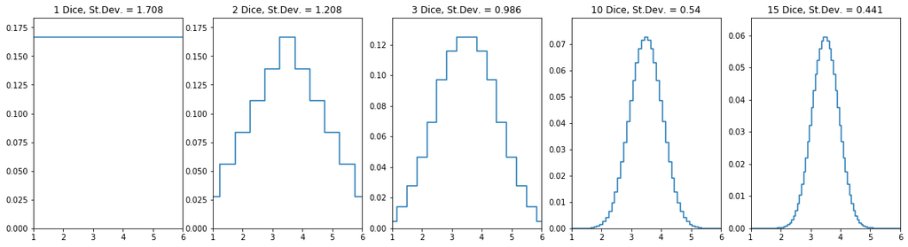

```python
plt.rcParams["figure.figsize"] = (20,5)
fig, ax = plt.subplots(1, 5)
dice = [1,2,3,10,15]
for i in range(0,5):
    plt.subplot(1,5,i+1)
    sDev = rollDice(dice[i],1/dice[i])
    plt.title(str(dice[i]) + " Dice, St.Dev. = " + str(round(sDev,3)))

plt.show()
```

Note how even 15 dice rolls has a tighter standard deviation and looks more Gaussian-like, the likeness won't stop getting better at 15 dice rolls either.  
Q5.

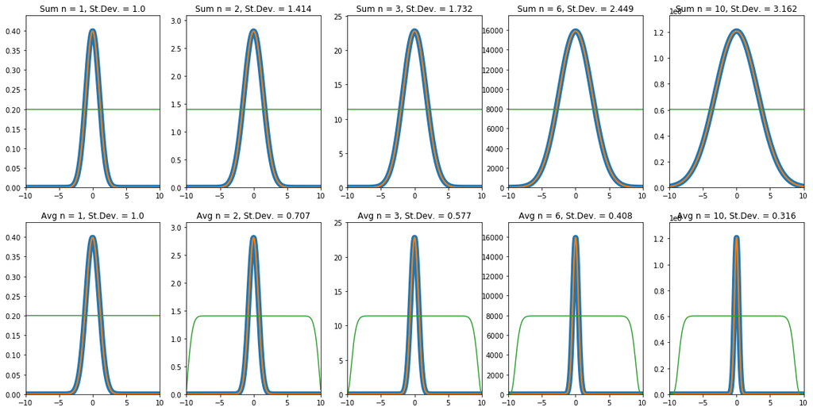

```python
def convGaussian(n,avg): # avg = 0 for sum, avg = 1 for average
    x = np.linspace(-10,10,200)
    f = stats.norm.pdf(x,0,1)
    F = f
    for i in range(0,n-1):
        F = np.convolve(F,f)

    if avg == 0:
        x = np.linspace(-10*n,10*n,len(F))
    elif avg == 1:
        x = np.linspace(-10,10,len(F))
    plt.ylim([0,1.1*max(F)])
    plt.plot(x,F,linewidth = 8)

    mean = sum(np.multiply(x,F))/sum(F)
    sqDiff = np.multiply(np.square(np.add(x,-mean)),F)/sum(F)
    variance = sum(sqDiff)
    sDev = math.sqrt(variance)

    gaussian = stats.norm.pdf(x,0,sDev)
    gaussian = np.multiply(gaussian,max(F)/max(gaussian))
    plt.plot(x,gaussian,linewidth = 2)
    plt.plot(x,0.5*max(F)*np.divide(F,gaussian))
    return sDev

plt.rcParams["figure.figsize"] = (20,10)
fig, ax = plt.subplots(2,5)
n = [1,2,3,6,10]
for i in range(0,5):
    plt.subplot(2,5,i+1)
    plt.xlim([-10,10])
    sDev = convGaussian(n[i],0)
    plt.title("Sum n = " + str(n[i]) + ", St.Dev. = " + str(round(sDev,3)))
for i in range(5,10):
    plt.subplot(2,5,i+1)
    plt.xlim([-10,10])
    sDev = convGaussian(n[i-5],1)
    plt.title("Avg n = " + str(n[i-5]) + ", St.Dev. = " + str(round(sDev,3)))

plt.show()
```

In these plots, the top row shows convolution sums of order n while the bottom row shows convolution averages of the same orders. The blue line represents the convolution, the orange line represents a Gaussian fit to the convolution, and the green line represents the ratio between the convolution and its fit (scaled to half the amplitude to show up on the graphs better). As you can see by the green line's flatness, the convolution adheres perfectly to the Gaussian fit (aside from the boundaries of the bottom row's plots), regardless of the order of convolution n. Because of that, I can say with fair certainty that any convolution of a Gaussian with itself will result in another Gaussian.

Conceptually speaking, the order of convolution n can represent the number of measurements taken, and the convolution itself is the background pdf that comes as a result of these measurements. If you were to add say 10 measured signals to each other, and each signal had a pdf of the original Gaussian, then the correlating plot of the new pdf for the sum of these signals would be the n = 10 summed plot. Since the summed convolutions become wider with higher orders of n, you'd likely end up with a higher probability of your summed-up measurement being a result of background noise. Contrary to this, if you were to average between 10 measured signals, and each signal's pdf was the original Gaussian, then you'd be looking at the pdf of the n = 10 average plot. The averaged convolutions become narrower with higher orders of n, so you'd end up with far less probability of your averaged measurement being background noise. To summarize this, summed-up convolutions are wider Gaussians than the original Gaussian, making the distance your net signal needs to be from the mean a larger requirement for a good signal, whereas averaged convolutions are narrower and have the opposite effect on the net signal's background noise.